# Test 1

JWP

2019 6 14

## Test 1

```r
library(dplyr)
```

```r
library(ggplot2)
```

#### 1. 다음의 문장을 좀더 효율적으로 개선하시오.

#### 1) vec1 <- c(1, 2, 3, 4, 5, 6)

```r
vec1 <- c(1:6); vec1
```

```
## [1] 1 2 3 4 5 6
```

#### 2) vec2 <- c(10, 9, 8, 7, 6, 5)

```r
vec2 <- c(10:5); vec2
```

```
## [1] 10  9  8  7  6  5
```

#### 3) vec3 <- c(1, 1, 2, 2, 3, 3)

```r
vec3 <- rep(1:3, each=2); vec3
```

```
## [1] 1 1 2 2 3 3
```

#### 4) vec4 <- c(1, 2, 3, 1, 2, 3)

```r
vec4 <- rep(1:3, 2); vec4
```

```
## [1] 1 2 3 1 2 3
```

#### 5) vec5 <- c(1, 3, 5, 7, 9, 11)

```r
vec5 <- seq(1, 11, 2); vec5
```

```
## [1]  1  3  5  7  9 11
```

### 2. 다음과 같이 네 명의 학생이 중간 시험과 기말 시험을 봤다.

#### 1) 위 자료를 데이터 프레임으로 만들어 df_score 라는 변수에 할당하시오.

```r
v1 <- c("강경학", "김태균", "이성열", "정은원")
v2 <- c(90, 78, 94, 70)
v3 <- c(50, 60, 90, 92)
df_score <- data.frame(이름=v1, 중간=v2, 기말=v3)
df_score
```

```
##     이름 중간 기말
## 1 강경학   90   50
## 2 김태균   78   60
## 3 이성열   94   90
## 4 정은원   70   92
```

#### 2) 위 자료에 평균이라는 필드를 추가하고 중간과 기말 시험의 평균을 구해서 평균이라는 필드에 할당하시오.

```r
df_score$평균 <- NA
for(i in 1:nrow(df_score)) {
  df_score$평균[i] <- mean(c(df_score$중간[i], df_score$기말[i]))
}
df_score
```

```
##     이름 중간 기말 평균
## 1 강경학   90   50   70
## 2 김태균   78   60   69
## 3 이성열   94   90   92
## 4 정은원   70   92   81
```

### 3. 2번 문제에 학점이라는 필드를 만들고, 평균 성적에 따라 학점을 부여하시오.

```r
df_score$학점 <- ""
for(i in 1:nrow(df_score)) {
  if(df_score$평균[i] >= 90){
    df_score$학점[i] <- "A"
  } else if(df_score$평균[i] >= 80){
    df_score$학점[i] <- "B"
  } else if(df_score$평균[i] >= 70){
    df_score$학점[i] <- "C"
  } else if(df_score$평균[i] >= 60){
    df_score$학점[i] <- "D"
  } else {
    df_score$학점[i] <- "F"
  }
}
df_score
```

```
##     이름 중간 기말 평균 학점
## 1 강경학   90   50   70    C
## 2 김태균   78   60   69    D
## 3 이성열   94   90   92    A
## 4 정은원   70   92   81    B
```

### 4. 양의 정수를 매개변수로 받아 1에서부터 매개변수 값까지 홀수를 더해서 그 결과를 리턴하는 함수 oddSum을 작성하고, oddSum(100)의 값을 계산해 보시오.

```r
oddSum <- function(num) {
  sum <- 1
  for(i in 2:num) {
    if(i %% 2 == 1) {
      sum <- sum + i
    }
  }
  return(sum)
}
oddSum(100)
```

```
## [1] 2500
```

### 5. R 내장 데이터인 “iris”를 이용하여 다음을 구하시오.

#### 1) “setosa” 종 Sepal.Width의 Box Plot을 그려 이상치를 확인할 것

```r
data1 <- select(subset(iris, Species == "setosa"), Sepal.Width)
data1
```

```
##    Sepal.Width
## 1          3.5
## 2          3.0
## 3          3.2
## 4          3.1
## 5          3.6
## 6          3.9
## 7          3.4
## 8          3.4
## 9          2.9
## 10         3.1
## 11         3.7
## 12         3.4
## 13         3.0
## 14         3.0
```

[output cut: 36 more lines]

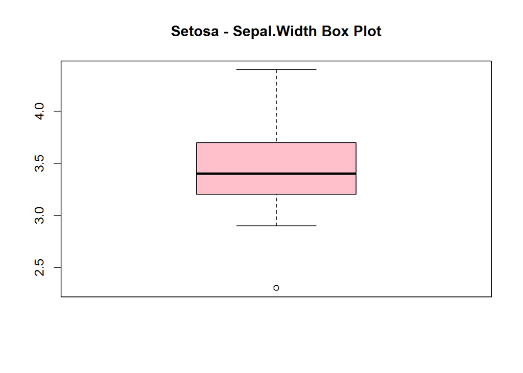

```r
boxplot(data1, col="pink", main="Setosa - Sepal.Width Box Plot")
```

#### 2) 이상치를 제거하기 전과 후의 평균과 표준편차

```r
data2 <- c(mean(data1$Sepal.Width), sd(data1$Sepal.Width))

for(i in 1:nrow(data1)) {
  if(data1[i,] < 2.5) print(i)
}
```

```
## [1] 42
```

```r
rdata1 <- data1[-42,]
data3 <- c(mean(rdata1), sd(rdata1))

data2
```

```
## [1] 3.4280000 0.3790644
```

```r
data3
```

```
## [1] 3.451020 0.345882
```

### 6. R 내장 데이터인 “mpg”를 이용하여 다음을 구하시오.

#### toyota에서 제작한 모델 중 시내주행연비(cty)와 고속도로주행연비(hwy)의  
#### 산술평균이 가장 좋은 3가지 모델과 평균연비

```r
top3 <- mpg %>%
  filter(manufacturer=="toyota") %>%
  group_by(model) %>%
  summarise_each(funs(mean), cty, hwy) %>%
  arrange(desc(cty, hwy)) %>%
  head(3)
top3
```

```
## # A tibble: 3 x 3
##   model          cty   hwy
##   <chr>        <dbl> <dbl>
## 1 corolla       25.6  34
## 2 camry         19.9  28.3
## 3 camry solara  19.9  28.1
```

### 7. R 내장 데이터인 "mpg를 이용하여 다음의 그래프를 그리시오.

#### 1) SUV 자동차의 시내 연비가 높은 7개 회사와 시내 연비

#### 2) 막대 그래프 형식의 컬러 그래프

```r
suv7 <- mpg %>%
  filter(class=="suv") %>%
  group_by(manufacturer) %>%
  summarise(average_cty=mean(cty)) %>%
  arrange(desc(average_cty)) %>%
  head(7)
suv7
```

```
## # A tibble: 7 x 2
##   manufacturer average_cty
##   <chr>              <dbl>
## 1 subaru              18.8
## 2 toyota              14.4
## 3 nissan              13.8
## 4 jeep                13.5
## 5 mercury             13.2
## 6 ford                12.9
## 7 chevrolet           12.7
```

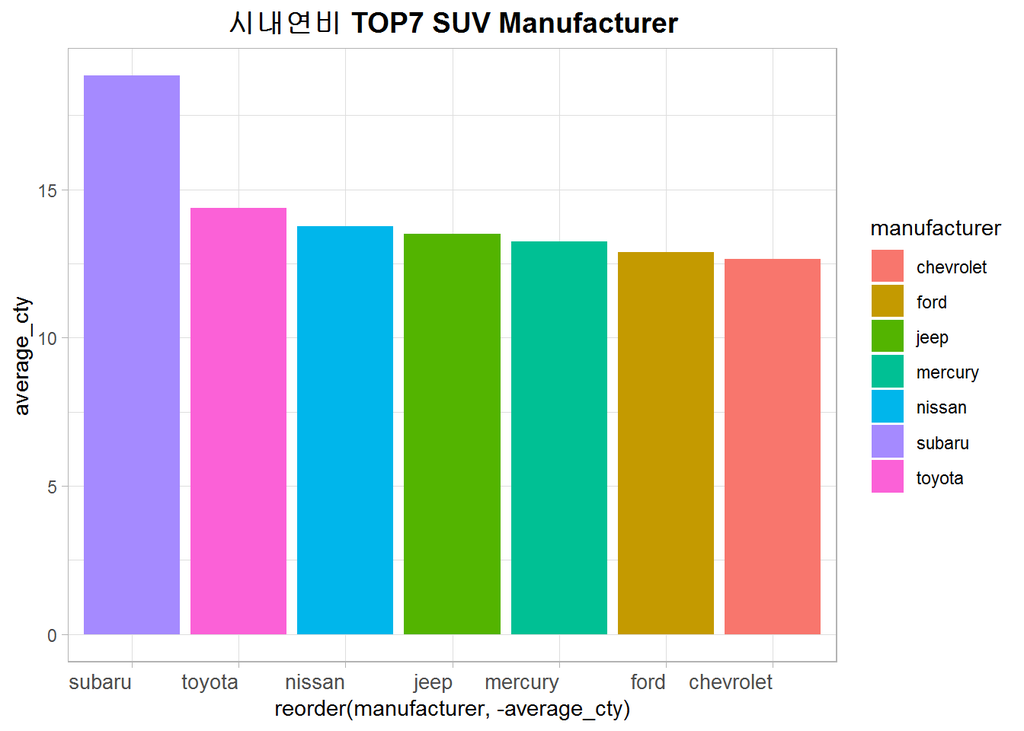

```r
ggplot(suv7, aes(x=reorder(manufacturer, -average_cty),
                 y=average_cty, fill=manufacturer)) +
  geom_bar(stat="identity") +
  theme_light() +
  ggtitle("시내연비 TOP7 SUV Manufacturer") +
  theme(plot.title = element_text(hjust=0.5, face="bold", size=14)) +
  theme(axis.text.x = element_text(hjust=1, vjust=1, size=10))
```

### 8. R 내장 데이터인 “diamonds”를 이용하여 다음의 그래프를 그리시오.

#### 1) clarity 의 돗수를 보여주는 그래프

```r
d <- diamonds %>%
  group_by(clarity) %>%
  summarise(count = n()) %>%
  arrange(count)
d
```

```
## # A tibble: 8 x 2
##   clarity count
##   <ord>   <int>
## 1 I1        741
## 2 IF       1790
## 3 VVS1     3655
## 4 VVS2     5066
## 5 VS1      8171
## 6 SI2      9194
## 7 VS2     12258
## 8 SI1     13065
```

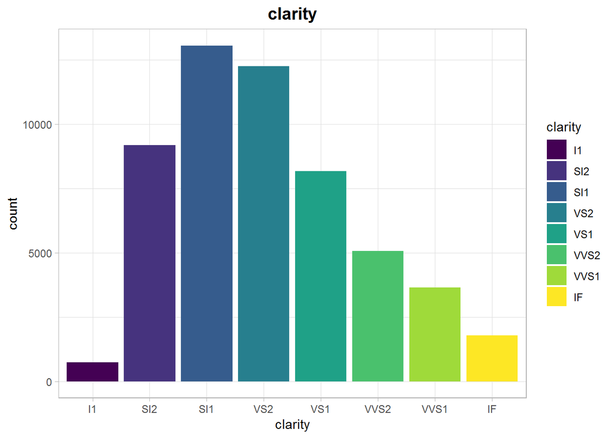

```r
ggplot(d, aes(x=clarity, y=count, fill=clarity)) + geom_histogram(stat="identity", position = "dodge") +
  theme_light() +
  ggtitle("clarity") +
  theme(plot.title = element_text(hjust=0.5, face="bold", size=14))
```

#### 2) clarity에 따른 가격의 변화를 보여주는 그래프

```r
d2 <- diamonds %>%
  group_by(clarity) %>%
  summarise(average_price = mean(price)) %>%
  arrange(average_price)
d2
```

```
## # A tibble: 8 x 2
##   clarity average_price
##   <ord>           <dbl>
## 1 VVS1            2523.
## 2 IF              2865.
## 3 VVS2            3284.
## 4 VS1             3839.
## 5 I1              3924.
## 6 VS2             3925.
## 7 SI1             3996.
## 8 SI2             5063.
```

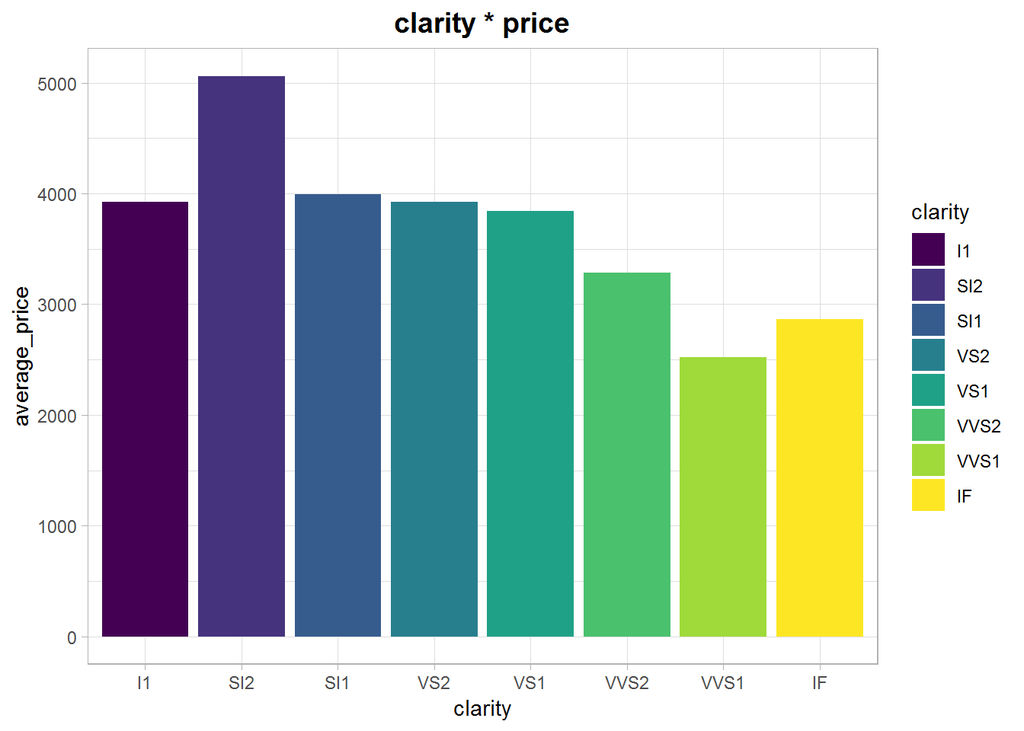

```r
ggplot(d2, aes(x=clarity, y=average_price, fill=clarity)) + geom_histogram(stat="identity", position = "dodge") +
  theme_light() +
  ggtitle("clarity * price") +
  theme(plot.title = element_text(hjust=0.5, face="bold", size=14))
```

### 9. 실습 데이터 중 야구성적.csv 파일을 이용하여 다음의 그래프를 그리시오.

#### 1) OPS(출루율+장타율)와 연봉대비 OPS(OPS/연봉*100)를 구하시오

```r
b <- read.csv("data/야구성적.csv")
b1 <- b %>%
  mutate(OPS = 출루율+장타율) %>%
  mutate(연봉대비OPS = OPS/연봉*100)
select(b1, 선수명, OPS, 연봉대비OPS)
```

```
##    선수명   OPS 연봉대비OPS
## 1  김태균 0.919    6.126667
## 2  박병호 1.039   20.780000
## 3    최정 0.980   14.000000
## 4  박석민 0.940   25.405405
## 5  손아섭 0.895   22.375000
## 6  정성훈 0.842   16.840000
## 7  배영섭 0.774   91.058824
## 8  나지완 0.868   43.400000
## 9  박정권 0.895   38.085106
## 10 박용택 0.828   23.657143
## 11 이진영 0.819   13.650000
## 12 최진행 0.826   48.588235
## 13 강정호 0.876   20.857143
## 14 민병헌 0.867   59.793103
## 15 이병규 0.839   10.487500
## 16 김현수 0.852   18.933333
## 17 홍성흔 0.818   20.450000
## 18 김종호 0.709   78.777778
## 19 이용규 0.742   10.600000
## 20 김강민 0.836   27.866667
## 21 이종욱 0.808   16.160000
## 22 정근우 0.776   11.085714
## 23 전준우 0.747   46.687500
## 24 최형우 0.896   19.911111
## 25 강민호 0.742    7.420000
```

#### 2) 연봉대비OPS를 선수별로 비교할 수 있는 막대그래프

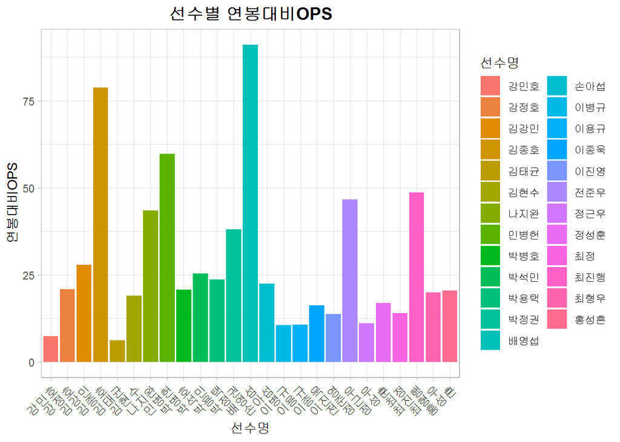

```r
ggplot(b1, aes(x=선수명, y=연봉대비OPS, fill=선수명)) + geom_bar(stat="identity") +
  theme_light() +
  ggtitle("선수별 연봉대비OPS") +
  theme(plot.title = element_text(hjust=0.5, face="bold", size=14)) +
  theme(axis.text.x = element_text(hjust=1, vjust=1, angle = 45, size=10))
```